# Pyramide des ages

jcb

22 août 2015

# 1 Solution avec epicalc

# 2 Solution avec ‘pyramid’

Application: http://freakonometrics.hypotheses.org/17885#more-17885

## 2.1 Drawing population pyramid using data.frame

Usage

pyramid(data, Laxis=NULL, Raxis=NULL, AxisFM=“g”, AxisBM=“”, AxisBI=3, Cgap=0.3, Cstep=1, Csize=1, Llab=“Males”, Rlab=“Females”, Clab=“Ages”, GL=TRUE, Cadj=-0.03, Lcol=“Cyan”, Rcol=“Pink”, Ldens=-1, Rdens=-1, main=“”, …) Arguments

**data** A data.frame including left pyramid numbers in the 1st column and and right pyramid numbers in the 2nd column, where the numbers of males in each age-class are usually given to left numbers and those of females are to right numbers. If the data.frame includes 3rd column, it is used as age-class labels, otherwise the row.names(data) is used as age-class labels.

Laxis A vector of axis for left pyramid. If missing, automatically given.

Raxis A vector of axis for right pyramid. If missing, Laxis is used.

AxisFM A format code of formatC for plotting axis. If missing, “g” is used.

AxisBM A big.mark of formatC for plotting axis. If missing, none.

AxisBI A big.interval number of formatC for plotting axis. Default is 3

Cgap The width of center gap (as ratio to each panel) to draw age-class. Default is 0.3

Cstep The interval to write the labels of age classes. Default is 1

Csize The font size factor to write the labels of age classes. Default is 1

Cadj The vertical adjustment factor for the labels of age classes. Default is -0.03

Llab The label of the left pyramid. Default is “Males”.

Rlab The label of the right pyramid. Default is “Females”.

Clab The label of the center age-class. Default is “Ages”.

GL Logical value to draw the vertical dotted lines. Default is TRUE.

Lcol The color of the left pyramid. Default is “Cyan”.

Ldens The density of hatching lines (/inch) for left pyramid. Default is -1, when the pyramid will be filled.

Rcol The color of the right pyramid. Default is “Pink”.

Rdens The density of hatching lines (/inch) for right pyramid. Default is -1, when the pyramid will be filled.

main The main title of the pyramid.

… Other options.

Examples:

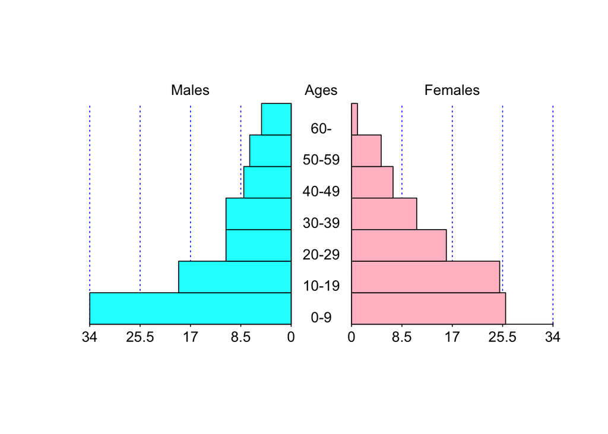

```r
ages <- c('0-9','10-19','20-29','30-39','40-49','50-59','60-')
males <- c(34,19,11,11,8,7,5)
females <- c(26,25,16,11,7,5,1)
data <- data.frame(males,females,ages)
pyramid(data)
```

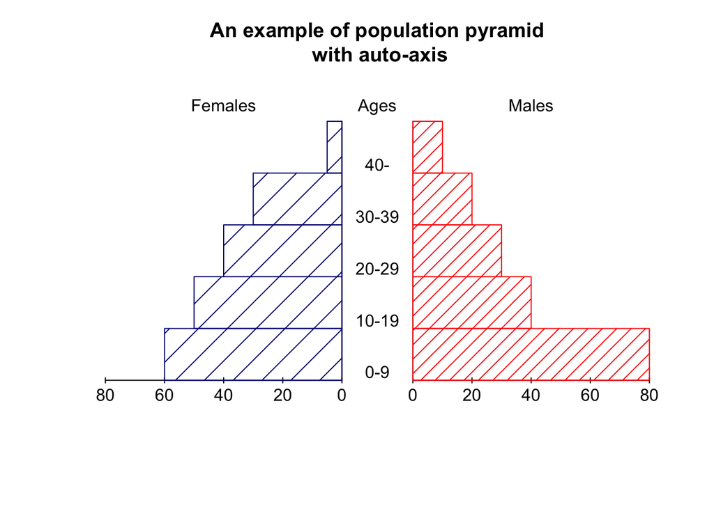

```r
# another example
py.Males <- c(80,40,30,20,10)
names(py.Males) <- c('0-9','10-19','20-29','30-39','40-')
py.Females <- c(60,50,40,30,5)
names(py.Females) <- names(py.Males)
py.df <- data.frame(py.Females,py.Males)
pyramid(py.df,Llab="Females",Rlab="Males",Lcol="navy", Ldens=5, Rcol="red",
 Rdens=10, GL=FALSE,main="An example of population pyramid\n with auto-axis")
```

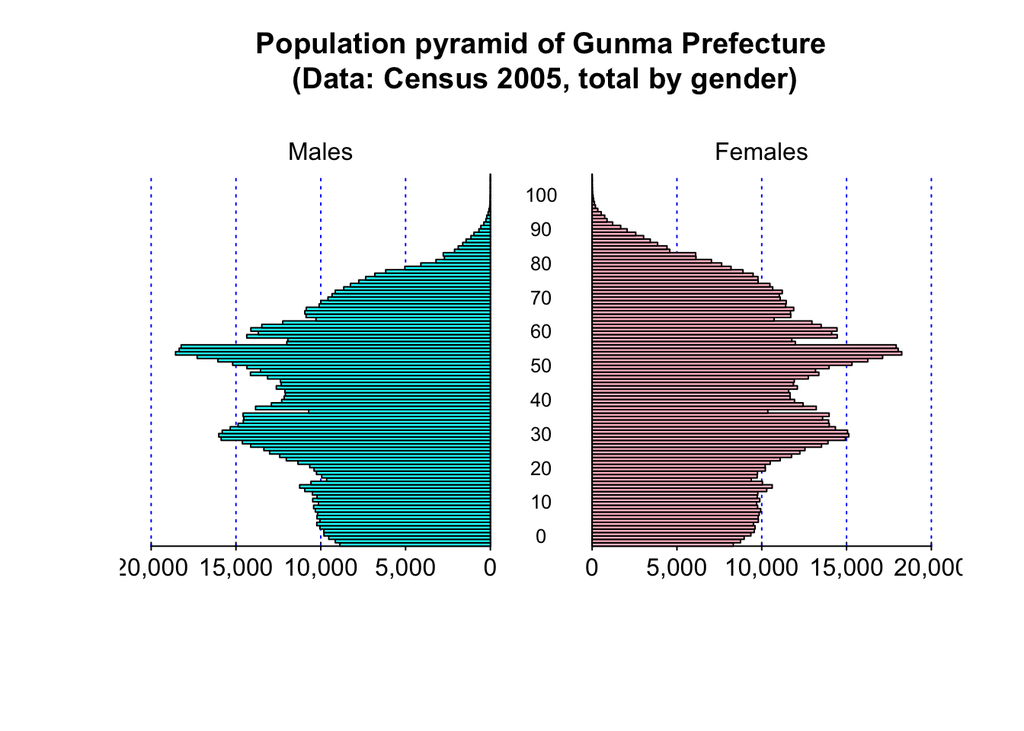

```r
# GunmaPop2005 is included in this package.
pyramid(GunmaPop2005,Llab="Males",Rlab="Females",Clab="",Laxis=seq(0,20000,len=5),
 AxisFM="d", AxisBM=",", Csize=0.8,  Cstep=10,
 main="Population pyramid of Gunma Prefecture\n (Data: Census 2005, total by gender)")
```

## 2.2 pyramidf

Drawing population pyramid using data.frame within the specified frame

Usage

pyramidf(data, Laxis=NULL, Raxis=NULL, frame=c(-1.15, 1.15, -0.05, 1.1), AxisFM=“g”, AxisBM=“”, AxisBI=3, Cgap=0.3, Cstep=1, Csize=1, Llab=“Males”, Rlab=“Females”, Clab=“Ages”, GL=TRUE, Cadj=-0.03, Lcol=“Cyan”, Rcol=“Pink”, Ldens=-1, Rdens=-1, main=“”, …) Arguments

data  
A data.frame including left pyramid numbers in the 1st column and and right pyramid numbers in the 2nd column, where the numbers of males in each age-class are usually given to left numbers and those of females are to right numbers. If the data.frame includes 3rd column, it is used as age-class labels, otherwise the row.names(data) is used as age-class labels.

Laxis  
A vector of axis for left pyramid. If missing, automatically given.

Raxis  
A vector of axis for right pyramid. If missing, Laxis is used.

AxisFM  
A format code of formatC for plotting axis. If missing, “g” is used.

AxisBM  
A big.mark of formatC for plotting axis. If missing, none.

AxisBI  
A big.interval number of formatC for plotting axis. Default is 3

Cgap  
The width of center gap (as ratio to each panel) to draw age-class. Default is 0.3

Cstep  
The interval to write the labels of age classes. Default is 1

Csize  
The font size factor to write the labels of age classes. Default is 1

Cadj  
The vertical adjustment factor for the labels of age classes. Default is -0.03

Llab  
The label of the left pyramid. Default is “Males”.

Rlab  
The label of the right pyramid. Default is “Females”.

Clab  
The label of the center age-class. Default is “Ages”.

GL  
Logical value to draw the vertical dotted lines. Default is TRUE.

Lcol  
The color of the left pyramid. Default is “Cyan”.

Ldens  
The density of hatching lines (/inch) for left pyramid. Default is -1, when the pyramid will be filled.

Rcol  
The color of the right pyramid. Default is “Pink”.

Rdens  
The density of hatching lines (/inch) for right pyramid. Default is -1, when the pyramid will be filled.

main  
The main title of the pyramid.

… Other options.

Author(s)

Minato Nakazawa minato-nakazawa@umin.net http://minato.sip21c.org/

Examples

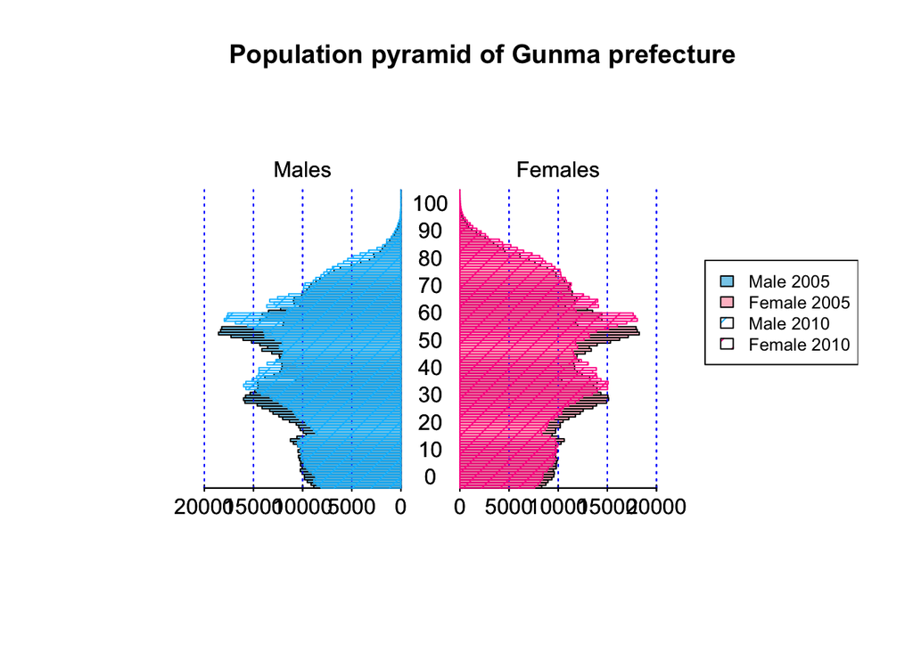

```r
# GunmaPop2005 and GumaPop2010 are included in this package.
plot(c(0,100), c(0,100), type="n", frame=FALSE, axes=FALSE, xlab="", ylab="",
 main="Population pyramid of Gunma prefecture")
# overlay
pyramidf(GunmaPop2005, frame=c(10, 75, 0, 90), Clab="", Lcol="skyblue", Rcol="pink",
 Cstep=10, Laxis=0:4*5000, AxisFM="d")
pyramidf(GunmaPop2010, frame=c(10, 75, 0, 90), Clab="", Lcol="deepskyblue", Rcol="deeppink",
 Ldens=10, Rdens=10, Cstep=10, Laxis=0:4*5000, AxisFM="d")
legend("right", fill=c("skyblue","pink","deepskyblue","deeppink"), density=c(NA,NA,10,10),
 legend=c("Male 2005", "Female 2005", "Male 2010", "Female 2010"), cex=0.8)
```

## 2.3 pyramids

Drawing population pyramid using vectors

Description

Drawing population pyramid using vectors. Detailed explanation is given in Japanese at http://minato.sip21c.org/swtips/R.html#PYRAMID.

Usage

pyramids(Left, Right, Center=NULL, …) Arguments

Left  
A vector of the numbers of people given for the left pyramid.

Right  
A vector of the numbers of people given for the right pyramid.

Center  
If given, a vector of the age-class labels to be drawn in center. If not given, names(Left) is used instead.

… This is the lapper function for pyramid(). All options for pyramid() can be passed.

Author(s)

Minato Nakazawa minato-nakazawa@umin.net http://minato.sip21c.org/

Examples

```r
py.Males <- c(80,40,30,20,10)
 names(py.Males) <- c('0-9','10-19','20-29','30-39','40-')
 py.Females <- c(60,50,40,30,5)
 pyramids(Left=py.Males,Llab="Males",Right=py.Females,Rlab="Females",
  Laxis=c(0,50,100),main="An example of population pyramid\n with fixed axis")
```

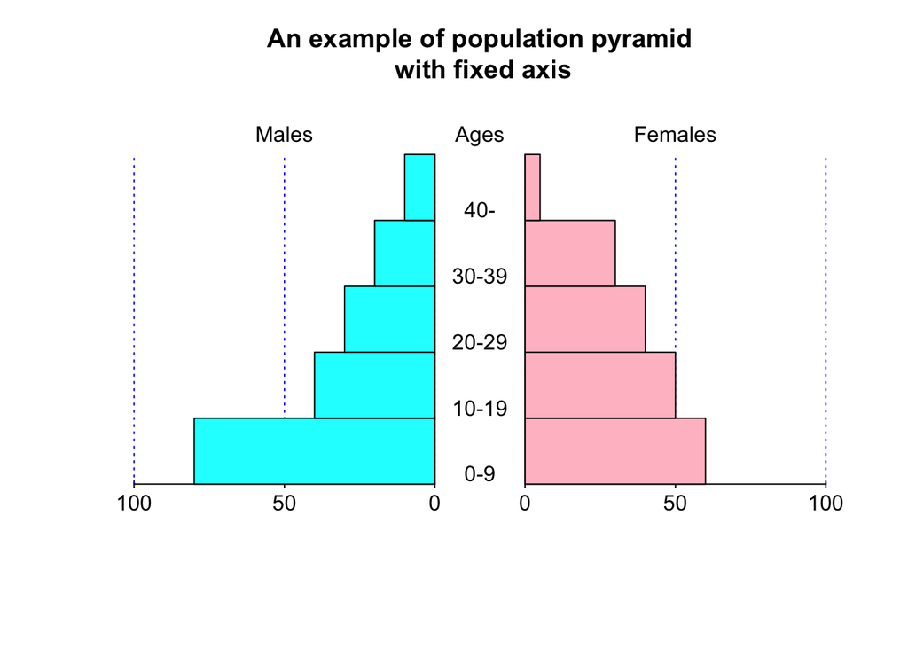

# 3 Solution avec rCharts

- Article: Interactive international population pyramids with R, rCharts
- Auteur: Sat 07 June 2014 by Kyle Walker
- source: http://walkerke.github.io/2014/06/rcharts-pyramids/
- source GitHub: http://walkerke.github.io/2014/06/rcharts-pyramids/

Donne plusieurs solutions pour plusieurs bibbliothèques javascript incluses dans **rCharts**. Toutes font appel à la fonction *getAgeTable* pour récupérer les données. C’est cette fonction qu’il faut adapter pour les données de l’INSEE par exemple. Ce programme permet de faire défiler plsieurs années.

## 3.1 Code

## 3.2 Script to generate population pyramids from the Census Bureau’s International Database with rCharts

```
library(XML)
library(reshape2)
library(rCharts)
library(plyr)


getAgeTable <- function(country, year) {
  c1 <- "http://www.census.gov/population/international/data/idb/region.php?N=%20Results%20&T=10&A=separate&RT=0&Y="
  c2 <- "&R=-1&C="
  yrs <- gsub(" ", "", toString(year))
  url <- paste0(c1, yrs, c2, country)
  df <- data.frame(readHTMLTable(url))
  nms <- c("Year", "Age", "total", "Male", "Female", "percent", "pctMale", "pctFemale", "sexratio")
  names(df) <- nms
  cols <- c(1, 3:9)
  df[,cols] <- apply(df[,cols], 2, function(x) as.numeric(as.character(gsub(",", "", x))))
  df <- df[df$Age != 'Total', ]
  ord <- 1:nrow(df)
  df <- cbind(df, ord)
  return(df)
}


# DimpleJS pyramid

dPyramid <- function(country, year, colors=NULL) {
  dat <- getAgeTable(country, year)
  dat$Male <- -1 * dat$Male

  keep <- c("Year", "Age", "Male", "Female", "ord")

  dat.sub <- dat[,keep]

  dat.melt <- melt(dat.sub,
                   value.name='Population',
                   variable.name = 'Gender',
                   id.vars=c('Age', 'ord', 'Year') )

  dat.melt$gencode <- ifelse(dat.melt$Gender == 'Male', 1, 2)

```

[output cut: 147 more lines]

```
                          } !#")
  } else {
    n1$yAxis(axisLabel = "Population",
             tickFormat = "#! function(d) {
                          return d3.format(',.0f')(Math.abs(d) / 1000) + 'K'
                          } !#")

  }

  if (!is.null(colors)) {
    n1$chart(color = colors)
  }

  n1
}
```